# Estadística y R para Ciencias de la Salud

Lídia Sànchez Camós

2024-11-16

## Actividad 1 - Representación gráfica de datos y análisis de resultados

Cargar librerias

```r
rm(list=ls())
library(ggplot2)
library(patchwork)
library(pheatmap)
```

Cargamos los datos de trabajo

```r
datos_genes <- read.csv("Dataset expresión genes.csv", sep = ",", header = TRUE)
names(datos_genes)
```

```
##   [1] "X"              "id"             "edad"           "sexo"
##   [5] "exfumador"      "hta"            "dm"             "alergia"
##   [9] "cardiopatia"    "ETE"            "neumopatia"     "hepatopatia"
##  [13] "colelitiasis"   "utolitiasis"    "ITU"            "renal"
##  [17] "neuropatia"     "corticoides"    "tos"            "disnea"
##  [21] "expect"         "secrecion"      "dolor_garg"     "escalofrios"
##  [25] "fiebre"         "diarrea"        "nauseas"        "vomitos"
##  [29] "cefalea"        "mareo"          "cansancio"      "anosmia"
##  [33] "disgueusia"     "dolor_hueso"    "dolor_abdo"     "perd_ape"
##  [37] "glucosa"        "leucocitos"     "linfocitos"     "neutrofilos"
##  [41] "score_dieta"    "chol"           "hdl"            "hierro"
##  [45] "igA"            "igE"            "igG"            "igN"
##  [49] "ldl"            "pcr"            "transferrina"   "trigliceridos"
##  [53] "cpk"            "calidad_fisica" "calidad_mental" "tumor"
##  [57] "extension"      "trat"           "AQ_ADIPOQ"      "AQ_ALOX5"
##  [61] "AQ_ARG1"        "AQ_BMP2"        "AQ_CCL2"        "AQ_CCL5"
##  [65] "AQ_CCR5"        "AQ_CD274"       "AQ_CD36"        "AQ_CHKA"
##  [69] "AQ_CPT1A"       "AQ_CSF2"        "AQ_CXCR1"       "AQ_FASN"
##  [73] "AQ_FOXO3"       "AQ_FOXP3"       "AQ_G6PD"        "AQ_GPD2"
##  [77] "AQ_GPX1"        "AQ_IFNG"        "AQ_IL10"        "AQ_IL1B"
##  [81] "AQ_IL6"         "AQ_IRS1"        "AQ_JAK1"        "AQ_JAK3"
##  [85] "AQ_LDHA"        "AQ_LIF"         "AQ_MAPK1"       "AQ_NFE2L2"
##  [89] "AQ_NFKB1"       "AQ_NLRP3"       "AQ_NOS2"        "AQ_NOX5"
##  [93] "AQ_PDCD1"       "AQ_PPARG"       "AQ_PTAFR"       "AQ_PTGS2"
##  [97] "AQ_SLC2A4"      "AQ_SOD1"        "AQ_SREBF1"      "AQ_STAT3"
## [101] "AQ_TGFB1"       "AQ_TLR3"        "AQ_TLR4"        "AQ_TNF"
```

Pregunta 1: Teniendo en cuenta los siguientes genes: AQ_ALOX5, AQ_CD274,AQ_CHKA, AQ_CSF2, AQ_FOXO3, AQ_IL6, AQ_LDHA, AQ_LIF, AQ_MAPK1, AQ_NOS2,AQ_IFNG, AQ_PDCD1, AQ_PPARG, AQ_TGFB1, AQ_TNF:

a). Para responder este ejercicio, apóyate en un diagrama de cajas en el que visualices por cada expresión de gen 2 cajas: 1 para tratA y otro para tratB.

Crear gráfico para cada gen (Boxplots)

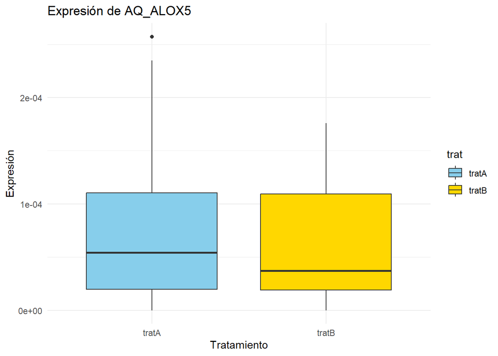

```r
plot_AQ_ALOX5 <- ggplot(datos_genes, aes(x = trat, y = AQ_ALOX5, fill = trat)) +
  geom_boxplot() +
  scale_fill_manual(values = c("tratA" = "skyblue", "tratB" = "gold"))+
  labs(title = "Expresión de AQ_ALOX5",
       x = "Tratamiento",
       y = "Expresión") +
  theme_minimal()

plot_AQ_ALOX5
```

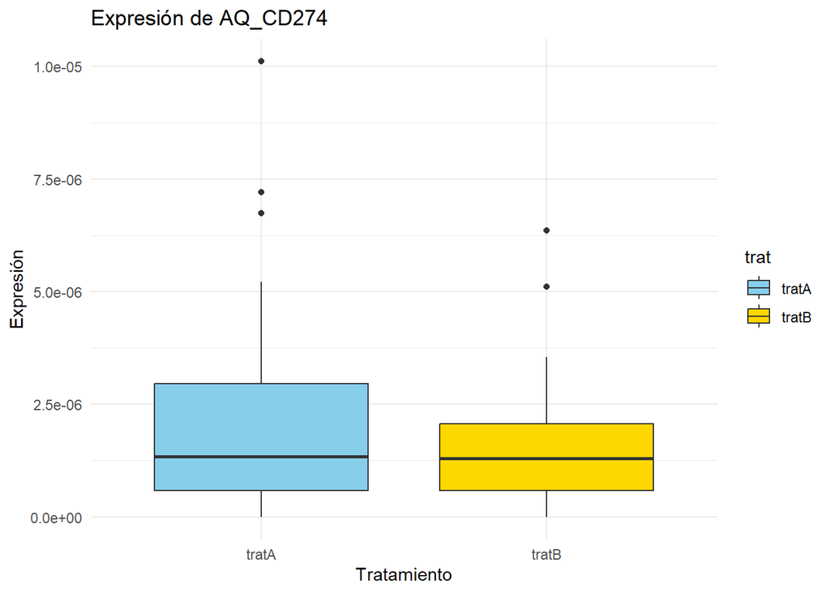

```r
plot_AQ_CD274 <- ggplot(datos_genes, aes(x = trat, y = AQ_CD274, fill = trat)) +
  geom_boxplot() +
  scale_fill_manual(values = c("tratA" = "skyblue", "tratB" = "gold"))+
  labs(title = "Expresión de AQ_CD274",
       x = "Tratamiento",
       y = "Expresión") +
  theme_minimal()

plot_AQ_CD274
```

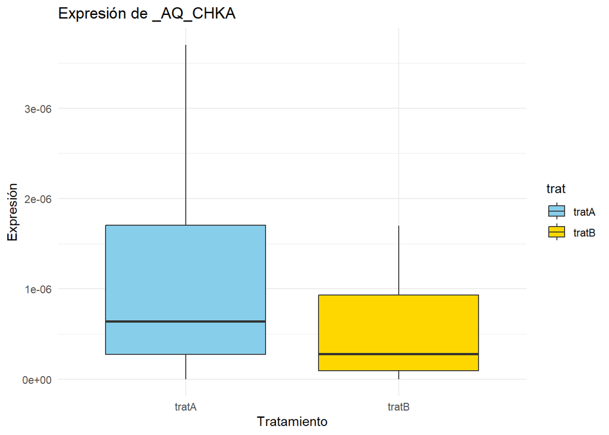

```r
plot_AQ_CHKA <- ggplot(datos_genes, aes(x = trat, y = AQ_CHKA, fill = trat)) +
  geom_boxplot() +
  scale_fill_manual(values = c("tratA" = "skyblue", "tratB" = "gold"))+
  labs(title = "Expresión de _AQ_CHKA",
       x = "Tratamiento",
       y = "Expresión") +
  theme_minimal()

plot_AQ_CHKA
```

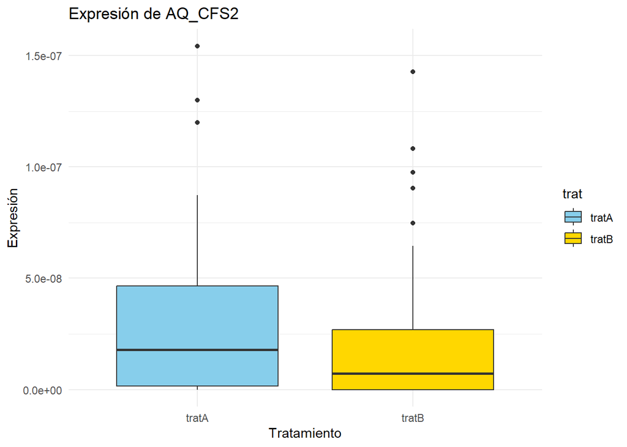

```r
plot_AQ_CSF2 <- ggplot(datos_genes, aes(x = trat, y = AQ_CSF2, fill = trat)) +
  geom_boxplot() +
  scale_fill_manual(values = c("tratA" = "skyblue", "tratB" = "gold"))+
  labs(title = "Expresión de AQ_CFS2",
       x = "Tratamiento",
       y = "Expresión") +
  theme_minimal()

plot_AQ_CSF2
```

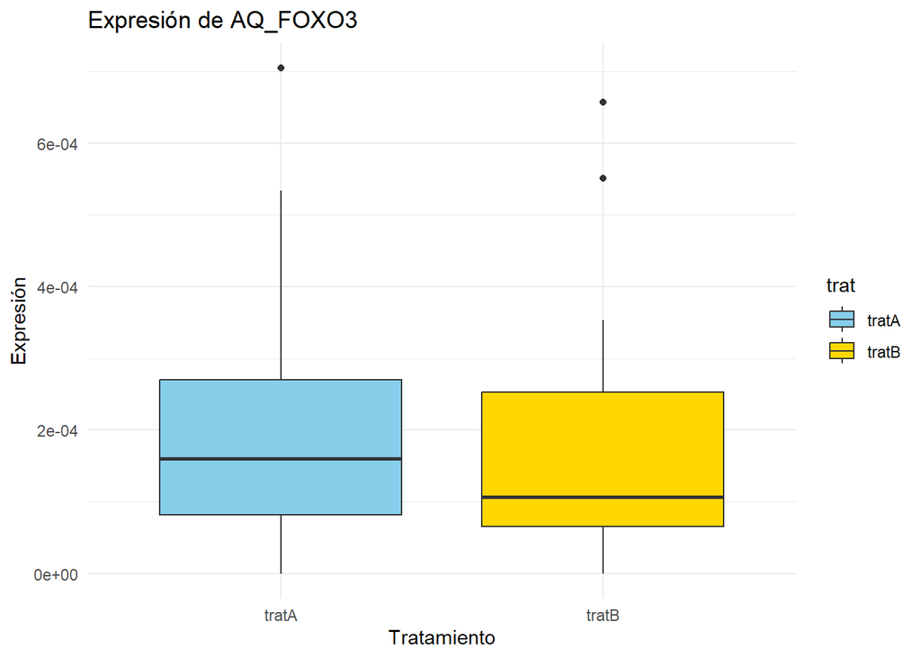

```r
plot_AQ_FOXO3 <- ggplot(datos_genes, aes(x = trat, y = AQ_FOXO3, fill = trat)) +
  geom_boxplot() +
  scale_fill_manual(values = c("tratA" = "skyblue", "tratB" = "gold"))+
  labs(title = "Expresión de AQ_FOXO3",
       x = "Tratamiento",
       y = "Expresión") +
  theme_minimal()

plot_AQ_FOXO3
```

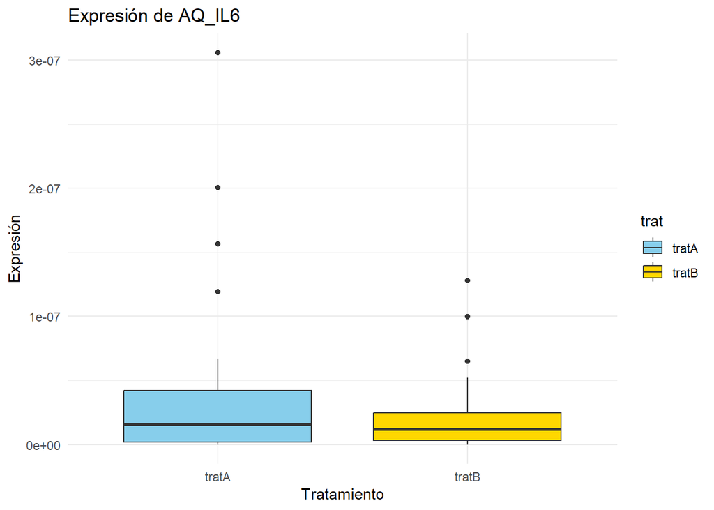

```r
plot_AQ_IL6 <- ggplot(datos_genes, aes(x = trat, y = AQ_IL6, fill = trat)) +
  geom_boxplot() +
  scale_fill_manual(values = c("tratA" = "skyblue", "tratB" = "gold"))+
  labs(title = "Expresión de AQ_IL6",
       x = "Tratamiento",
       y = "Expresión") +
  theme_minimal()

plot_AQ_IL6
```

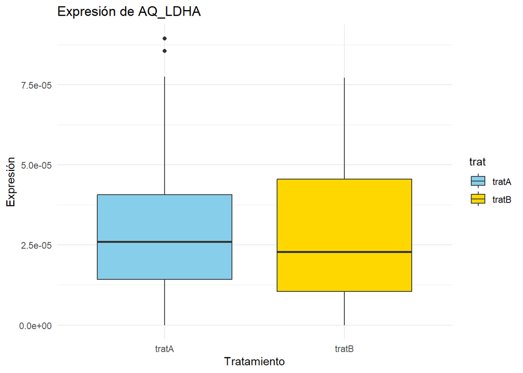

```r
plot_AQ_LDHA <- ggplot(datos_genes, aes(x = trat, y = AQ_LDHA, fill = trat)) +
  geom_boxplot() +
  scale_fill_manual(values = c("tratA" = "skyblue", "tratB" = "gold"))+
  labs(title = "Expresión de AQ_LDHA",
       x = "Tratamiento",
       y = "Expresión") +
  theme_minimal()

plot_AQ_LDHA
```

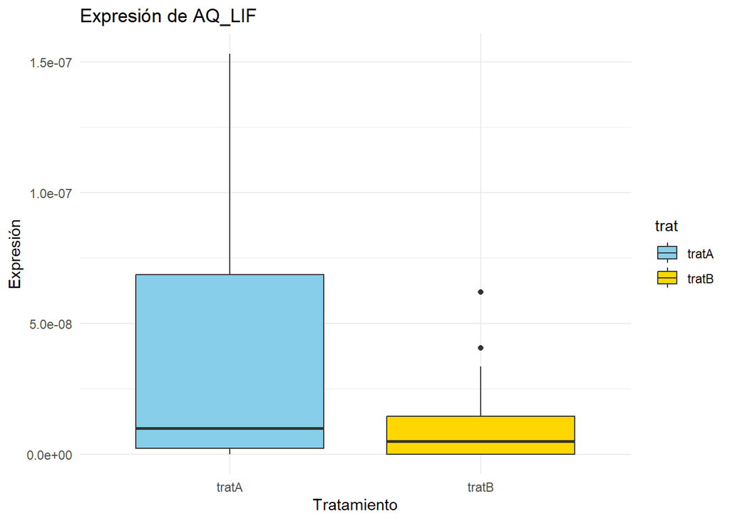

```r
plot_AQ_LIF <- ggplot(datos_genes, aes(x = trat, y = AQ_LIF, fill = trat)) +
  geom_boxplot() +
  scale_fill_manual(values = c("tratA" = "skyblue", "tratB" = "gold"))+
  labs(title = "Expresión de AQ_LIF",
       x = "Tratamiento",
       y = "Expresión") +
  theme_minimal()

plot_AQ_LIF
```

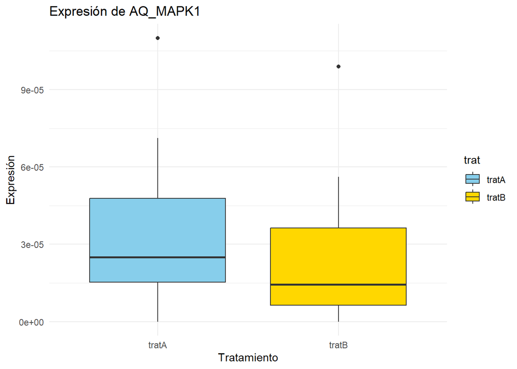

```r
plot_AQ_MAPK1 <- ggplot(datos_genes, aes(x = trat, y = AQ_MAPK1, fill = trat)) +
  geom_boxplot() +
  scale_fill_manual(values = c("tratA" = "skyblue", "tratB" = "gold"))+
  labs(title = "Expresión de AQ_MAPK1",
       x = "Tratamiento",
       y = "Expresión") +
  theme_minimal()

plot_AQ_MAPK1
```

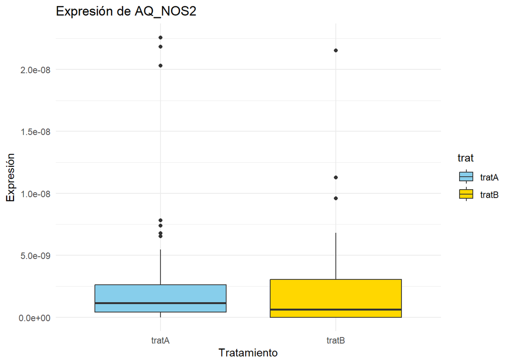

```r
plot_AQ_NOS2 <- ggplot(datos_genes, aes(x = trat, y = AQ_NOS2, fill = trat)) +
  geom_boxplot() +
  scale_fill_manual(values = c("tratA" = "skyblue", "tratB" = "gold"))+
  labs(title = "Expresión de AQ_NOS2",
       x = "Tratamiento",
       y = "Expresión") +
  theme_minimal()

plot_AQ_NOS2
```

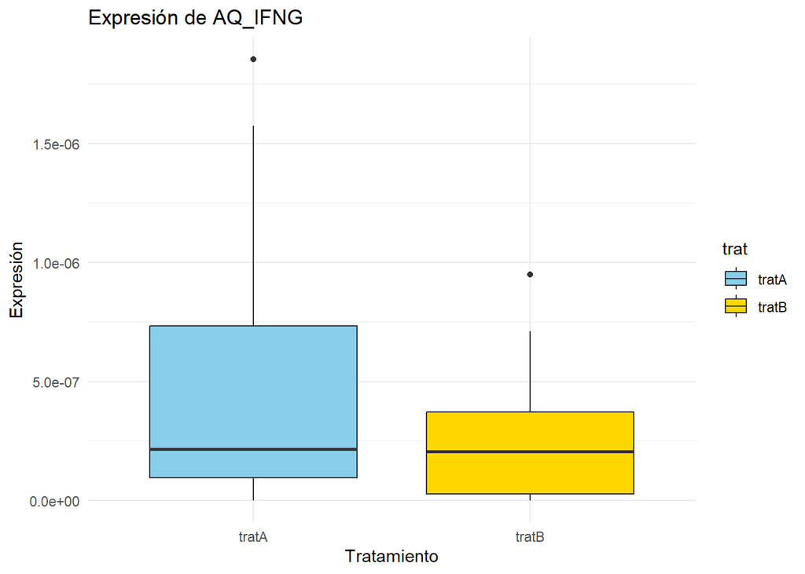

```r
plot_AQ_IFNG <- ggplot(datos_genes, aes(x = trat, y = AQ_IFNG, fill = trat)) +
  geom_boxplot() +
  scale_fill_manual(values = c("tratA" = "skyblue", "tratB" = "gold"))+
  labs(title = "Expresión de AQ_IFNG",
       x = "Tratamiento",
       y = "Expresión") +
  theme_minimal()

plot_AQ_IFNG
```

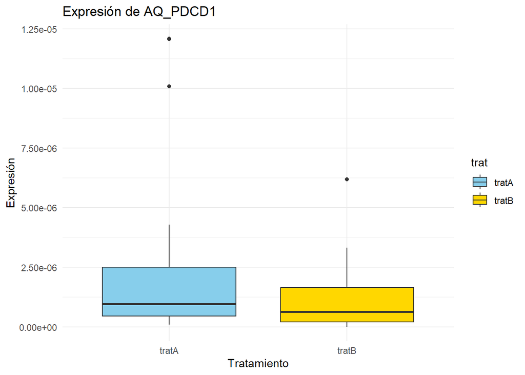

```r
plot_AQ_PDCD1 <- ggplot(datos_genes, aes(x = trat, y = AQ_PDCD1, fill = trat)) +
  geom_boxplot() +
  scale_fill_manual(values = c("tratA" = "skyblue", "tratB" = "gold"))+
  labs(title = "Expresión de AQ_PDCD1",
       x = "Tratamiento",
       y = "Expresión") +
  theme_minimal()

plot_AQ_PDCD1
```

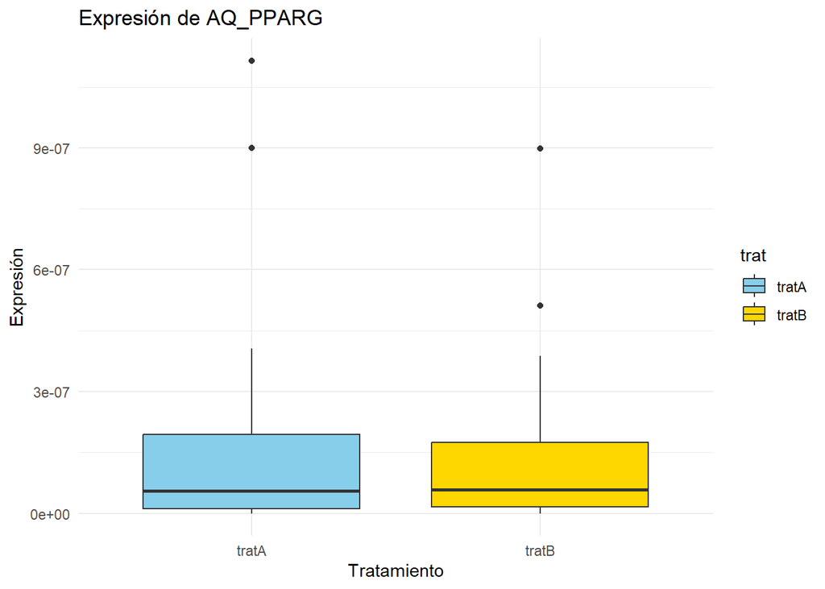

```r
plot_AQ_PPARG <- ggplot(datos_genes, aes(x = trat, y = AQ_PPARG, fill = trat)) +
  geom_boxplot() +
  scale_fill_manual(values = c("tratA" = "skyblue", "tratB" = "gold"))+
  labs(title = "Expresión de AQ_PPARG",
       x = "Tratamiento",
       y = "Expresión") +
  theme_minimal()

plot_AQ_PPARG
```

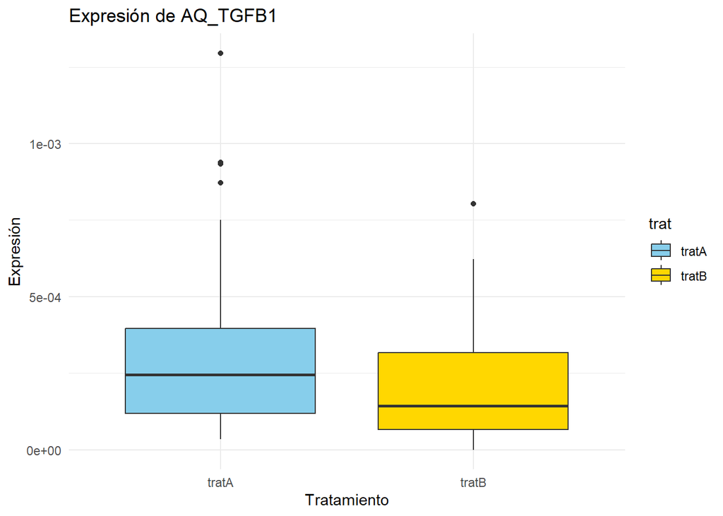

```r
plot_AQ_TGFB1 <- ggplot(datos_genes, aes(x = trat, y = AQ_TGFB1, fill = trat)) +
  geom_boxplot() +
  scale_fill_manual(values = c("tratA" = "skyblue", "tratB" = "gold"))+
  labs(title = "Expresión de AQ_TGFB1",
       x = "Tratamiento",
       y = "Expresión") +
  theme_minimal()

plot_AQ_TGFB1
```

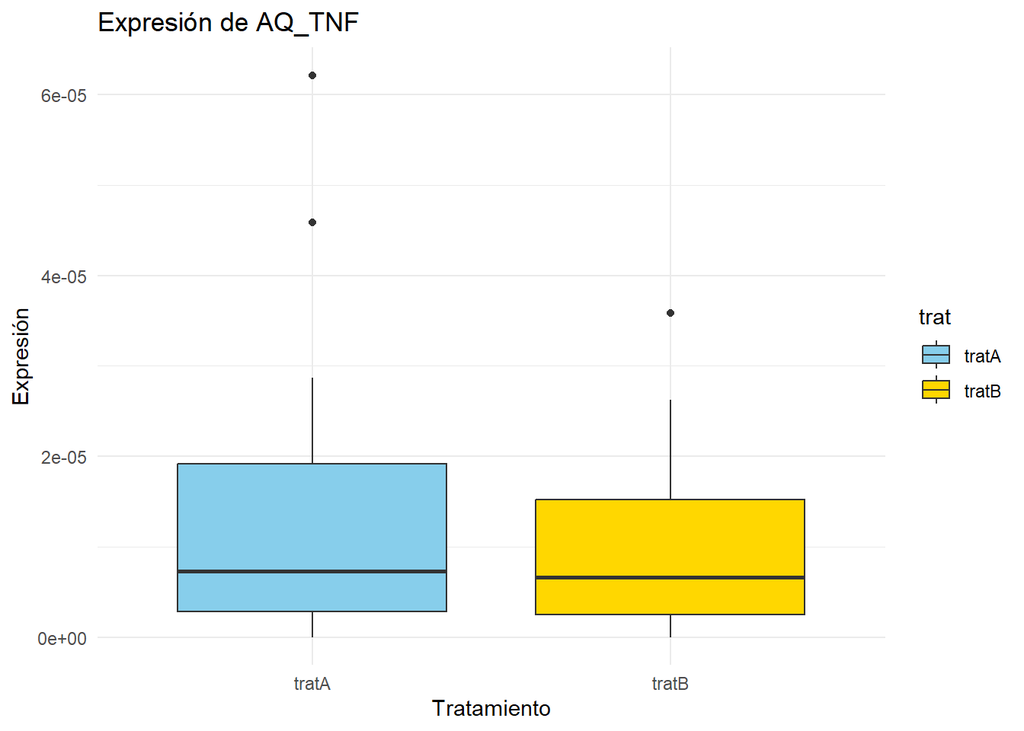

```r
plot_AQ_TNF <- ggplot(datos_genes, aes(x = trat, y = AQ_TNF, fill = trat)) +
  geom_boxplot() +
  scale_fill_manual(values = c("tratA" = "skyblue", "tratB" = "gold"))+
  labs(title = "Expresión de AQ_TNF",
       x = "Tratamiento",
       y = "Expresión") +
  theme_minimal()

plot_AQ_TNF
```

Combinar los gráficos en un solo layout con 3 columnas con Patchwork

[figure not shown]

```r
combined_plot <- plot_AQ_ALOX5 + plot_AQ_CD274 + plot_AQ_CHKA + plot_AQ_CSF2 +
  plot_AQ_FOXO3 + plot_AQ_IL6 + plot_AQ_LDHA + plot_AQ_LIF +
  plot_AQ_MAPK1 + plot_AQ_NOS2 + plot_AQ_IFNG + plot_AQ_PDCD1 +
  plot_AQ_PPARG + plot_AQ_TGFB1 + plot_AQ_TNF +
  plot_layout(ncol = 3)

combined_plot
```

b). ¿Qué interpretación sacas de la distribución de la expresión de los genes cuando los comparamos por tipo de tratamiento?

Los gráficos de cajas muestran que algunos genes, como AQ_ALOX5 y AQ_CHKA, tienen niveles de expresión más altos en un tratamiento que en otro. Esto sugiere que los tratamientos podrían estar afectando de manera diferente procesos relacionados con la inflamación y el metabolismo lipídico. Por ejemplo, AQ_ALOX5, que participa en la síntesis de leucotrienos, puede estar más activo en pacientes bajo tratA, lo que indicaría una influencia directa en las vías inflamatorias [1,2].

Por otro lado, genes asociados a la respuesta inmune, como AQ_IL6 y AQ_TNF, muestran mucha variabilidad en sus niveles de expresión, con valores atípicos destacados. Esto podría deberse a diferencias individuales entre los pacientes o a estados de salud específicos antes del tratamiento. Estas citoquinas desempeñan un papel clave en la inflamación y podrían ser útiles para predecir qué pacientes responderían mejor al tratamiento [3,4].

La variabilidad observada en genes clave subraya la importancia de analizar las diferencias individuales. Esto podría ayudar a identificar tratamientos más efectivos o a reducir posibles efectos secundarios, dependiendo del perfil genético de cada paciente [3,6].

Pregunta 2:Teniendo en cuenta los siguientes parámetros bioquímicos para toda la población: glucosa, leucocitos, linfocitos, neutrofilos, chol, hdl, hierro, igA, igE, igG, igN, ldl, pcr, transferrina, trigliceridos, cpk:

a). Para responder este ejercicio, apóyate en un histograma en el que se visualice la frecuencia de cada variable utilizando aproximadamente 30 bins (a mayor bins, mayor número de barras).

Cargamos las librerias para este apartado

```r
library(ggplot2)
```

Creamos un ggplot para cada variable

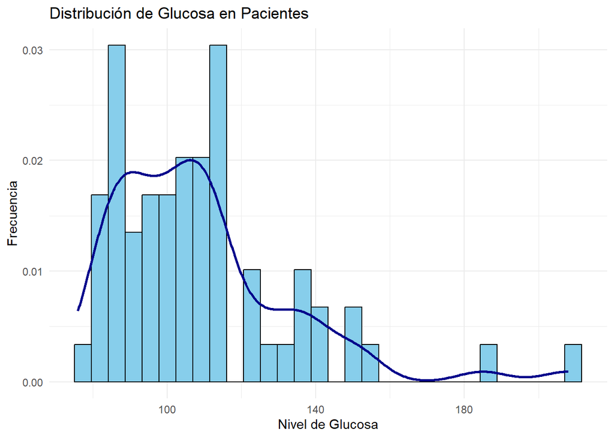

```r
histo_Glucosa <-ggplot(data = datos_genes, aes(x = glucosa)) +
  geom_histogram(aes(y = ..density..),bins = 30, fill = "skyblue", color = "black") +
  geom_density(color = "darkblue", linewidth = 1) +
  labs(title = "Distribución de Glucosa en Pacientes",
       x = "Nivel de Glucosa", y = "Frecuencia") +
  theme_minimal()

histo_Glucosa
```

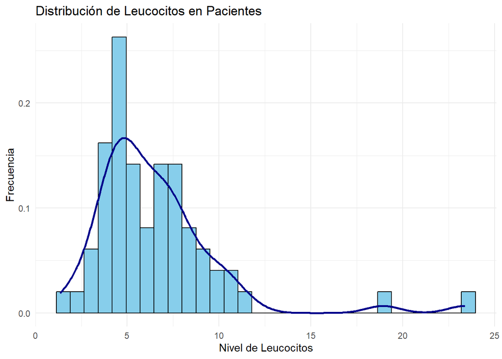

```r
histo_Leucocitos <-ggplot(data = datos_genes, aes(x = leucocitos)) +
  geom_histogram(aes(y = ..density..),bins = 30, fill = "skyblue", color = "black") +
  geom_density(color = "darkblue", linewidth = 1) +
  labs(title = "Distribución de Leucocitos en Pacientes",
       x = "Nivel de Leucocitos", y = "Frecuencia") +
  theme_minimal()

histo_Leucocitos
```

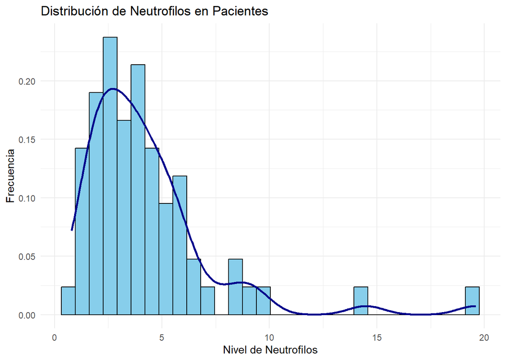

```r
histo_Neutrofilos <-ggplot(data = datos_genes, aes(x = neutrofilos)) +
  geom_histogram(aes(y = ..density..),bins = 30, fill = "skyblue", color = "black") +
  geom_density(color = "darkblue", linewidth = 1) +
  labs(title = "Distribución de Neutrofilos en Pacientes",
       x = "Nivel de Neutrofilos", y = "Frecuencia") +
  theme_minimal()

histo_Neutrofilos
```

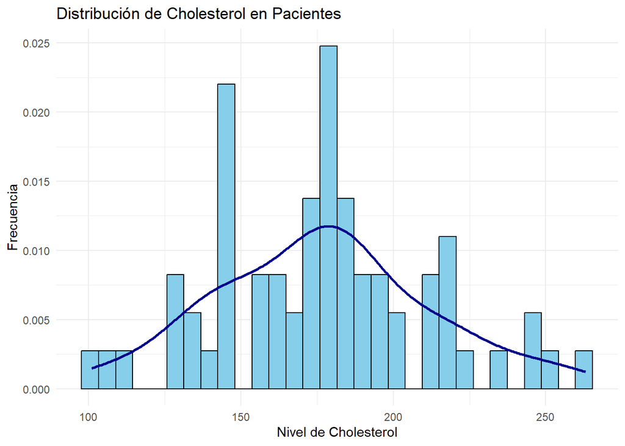

```r
histo_Chol <-ggplot(data = datos_genes, aes(x = chol)) +
  geom_histogram(aes(y = ..density..),bins = 30, fill = "skyblue", color = "black") +
  geom_density(color = "darkblue", linewidth = 1) +
  labs(title = "Distribución de Cholesterol en Pacientes",
       x = "Nivel de Cholesterol", y = "Frecuencia") +
  theme_minimal()

histo_Chol
```

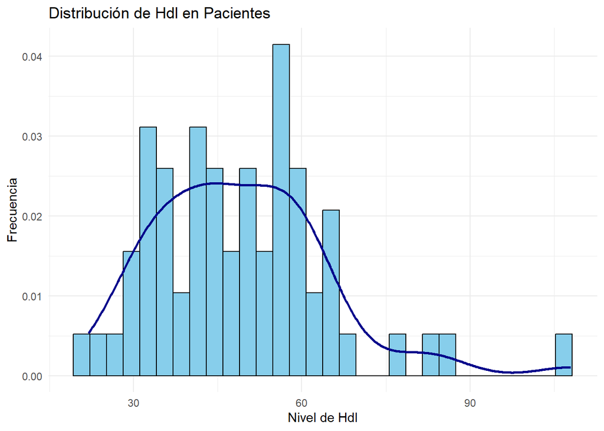

```r
histo_Hdl <-ggplot(data = datos_genes, aes(x = hdl)) +
  geom_histogram(aes(y = ..density..),bins = 30, fill = "skyblue", color = "black") +
  geom_density(color = "darkblue", linewidth = 1) +
  labs(title = "Distribución de Hdl en Pacientes",
       x = "Nivel de Hdl", y = "Frecuencia") +
  theme_minimal()

histo_Hdl
```

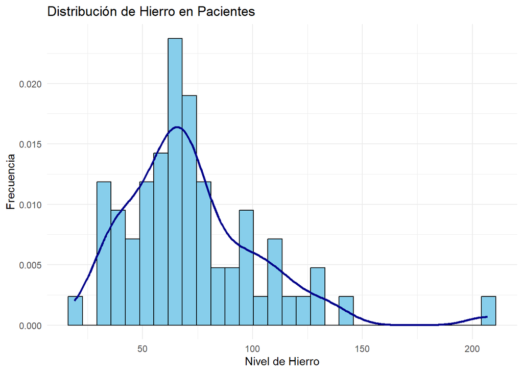

```r
histo_Hierro <-ggplot(data = datos_genes, aes(x = hierro)) +
  geom_histogram(aes(y = ..density..),bins = 30, fill = "skyblue", color = "black") +
  geom_density(color = "darkblue", linewidth = 1) +
  labs(title = "Distribución de Hierro en Pacientes",
       x = "Nivel de Hierro", y = "Frecuencia") +
  theme_minimal()

histo_Hierro
```

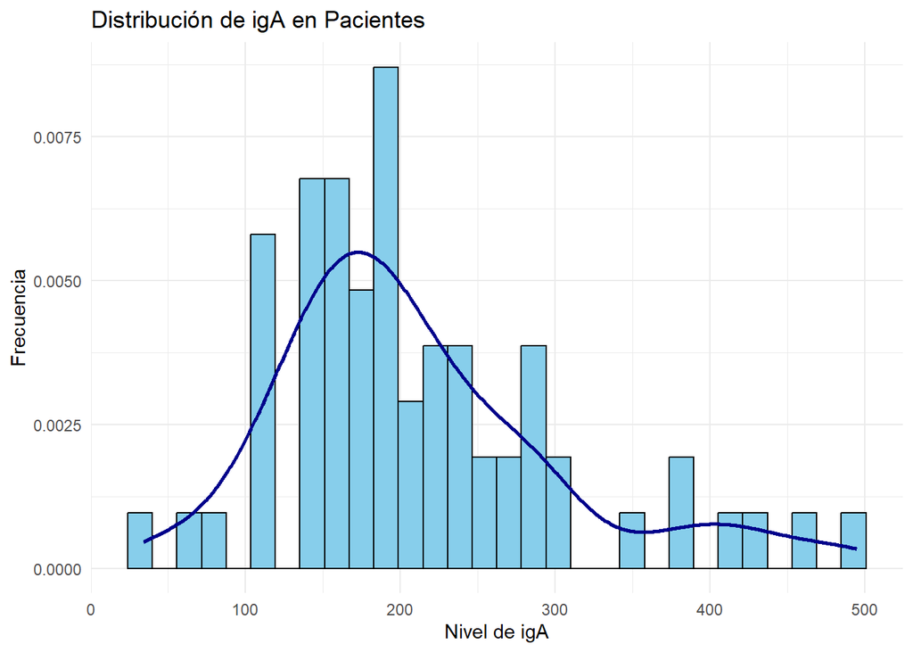

```r
histo_igA <-ggplot(data = datos_genes, aes(x = igA)) +
  geom_histogram(aes(y = ..density..),bins = 30, fill = "skyblue", color = "black") +
  geom_density(color = "darkblue", linewidth = 1) +
  labs(title = "Distribución de igA en Pacientes",
       x = "Nivel de igA", y = "Frecuencia") +
  theme_minimal()

histo_igA
```

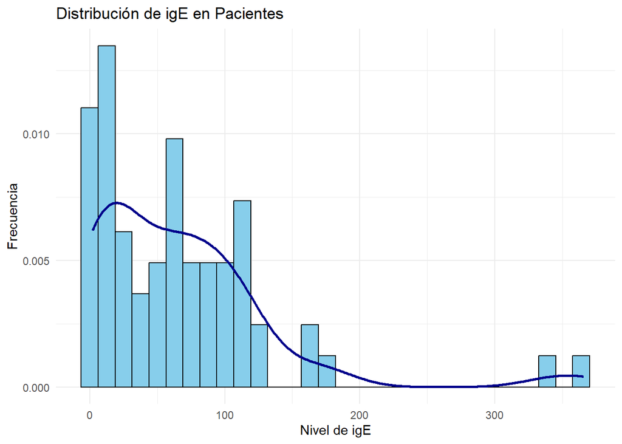

```r
histo_igE <-ggplot(data = datos_genes, aes(x = igE)) +
  geom_histogram(aes(y = ..density..),bins = 30, fill = "skyblue", color = "black") +
  geom_density(color = "darkblue", linewidth = 1) +
  labs(title = "Distribución de igE en Pacientes",
       x = "Nivel de igE", y = "Frecuencia") +
  theme_minimal()

histo_igE
```

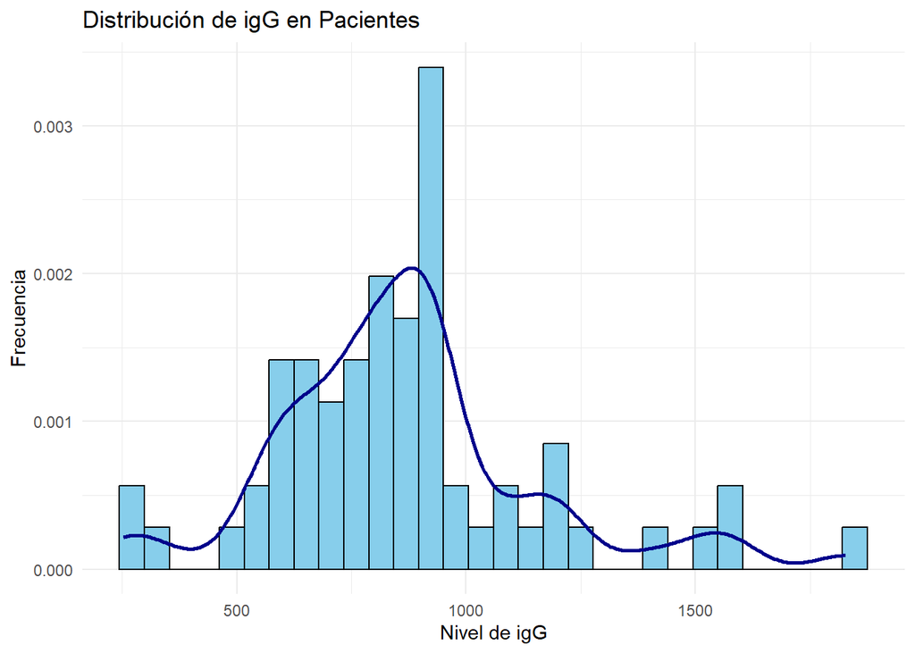

```r
histo_igG <-ggplot(data = datos_genes, aes(x = igG)) +
  geom_histogram(aes(y = ..density..),bins = 30, fill = "skyblue", color = "black") +
  geom_density(color = "darkblue", linewidth = 1) +
  labs(title = "Distribución de igG en Pacientes",
       x = "Nivel de igG", y = "Frecuencia") +
  theme_minimal()

histo_igG
```

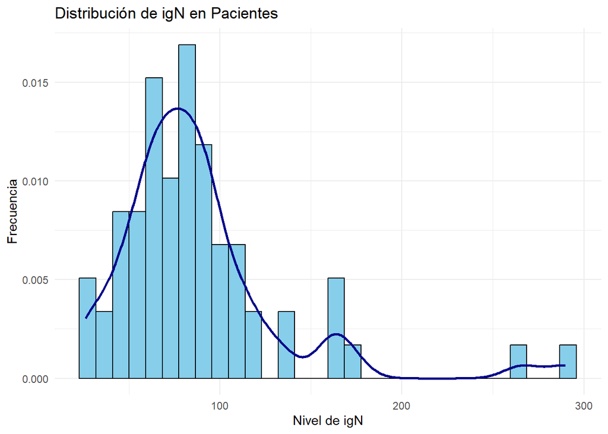

```r
histo_igN <-ggplot(data = datos_genes, aes(x = igN)) +
  geom_histogram(aes(y = ..density..),bins = 30, fill = "skyblue", color = "black") +
  geom_density(color = "darkblue", linewidth = 1) +
  labs(title = "Distribución de igN en Pacientes",
       x = "Nivel de igN", y = "Frecuencia") +
  theme_minimal()

histo_igN
```

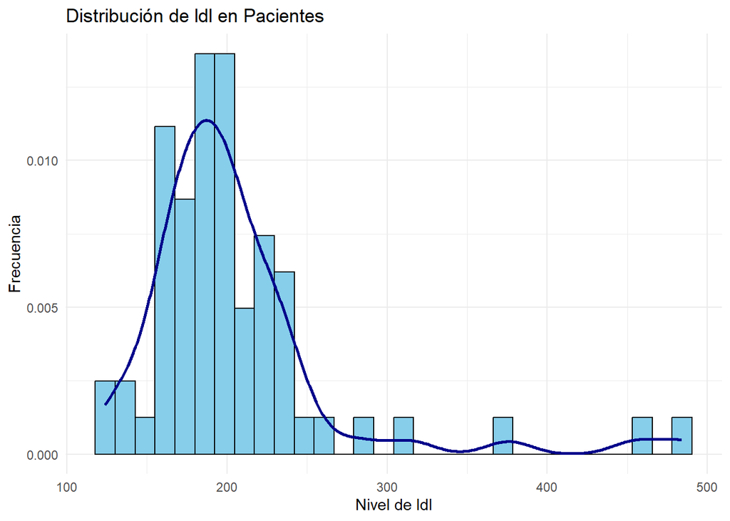

```r
histo_ldl <-ggplot(data = datos_genes, aes(x = ldl)) +
  geom_histogram(aes(y = ..density..),bins = 30, fill = "skyblue", color = "black") +
  geom_density(color = "darkblue", linewidth = 1) +
  labs(title = "Distribución de ldl en Pacientes",
       x = "Nivel de ldl", y = "Frecuencia") +
  theme_minimal()

histo_ldl
```

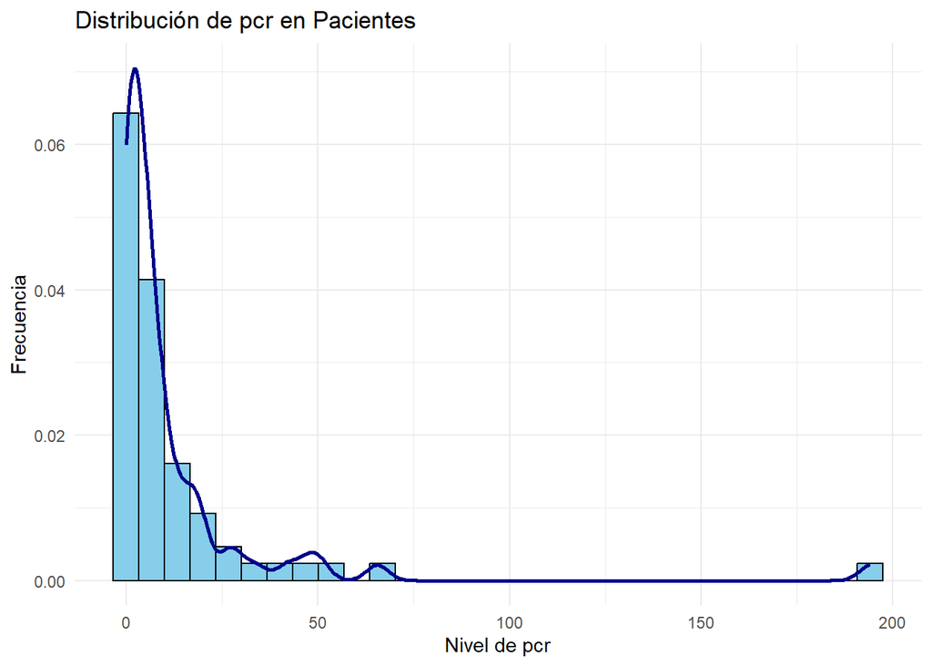

```r
histo_pcr <-ggplot(data = datos_genes, aes(x = pcr)) +
  geom_histogram(aes(y = ..density..),bins = 30, fill = "skyblue", color = "black") +
   geom_density(color = "darkblue", linewidth = 1) +
  labs(title = "Distribución de pcr en Pacientes",
       x = "Nivel de pcr", y = "Frecuencia") +
  theme_minimal()

histo_pcr
```

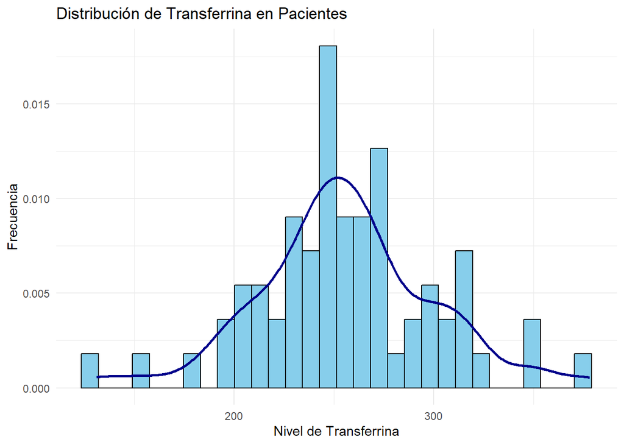

```r
histo_Transferrina <-ggplot(data = datos_genes, aes(x = transferrina)) +
  geom_histogram(aes(y = ..density..),bins = 30, fill = "skyblue", color = "black") +
  geom_density(color = "darkblue", linewidth = 1) +
  labs(title = "Distribución de Transferrina en Pacientes",
       x = "Nivel de Transferrina", y = "Frecuencia") +
  theme_minimal()

histo_Transferrina
```

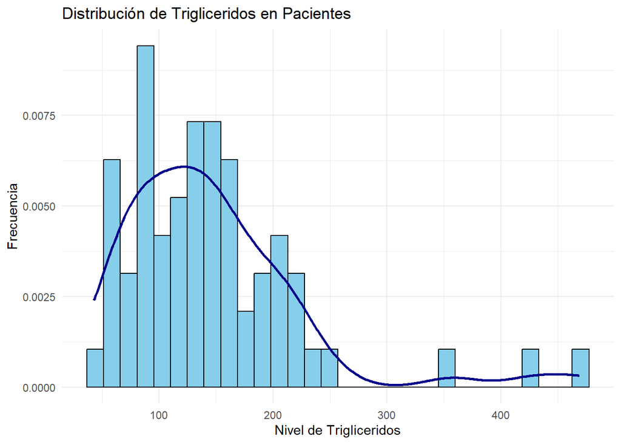

```r
histo_Trigliceridos <-ggplot(data = datos_genes, aes(x = trigliceridos)) +
  geom_histogram(aes(y = ..density..),bins = 30, fill = "skyblue", color = "black") +
  geom_density(color = "darkblue", linewidth = 1) +
  labs(title = "Distribución de Trigliceridos en Pacientes",
       x = "Nivel de Trigliceridos", y = "Frecuencia") +
  theme_minimal()

histo_Trigliceridos
```

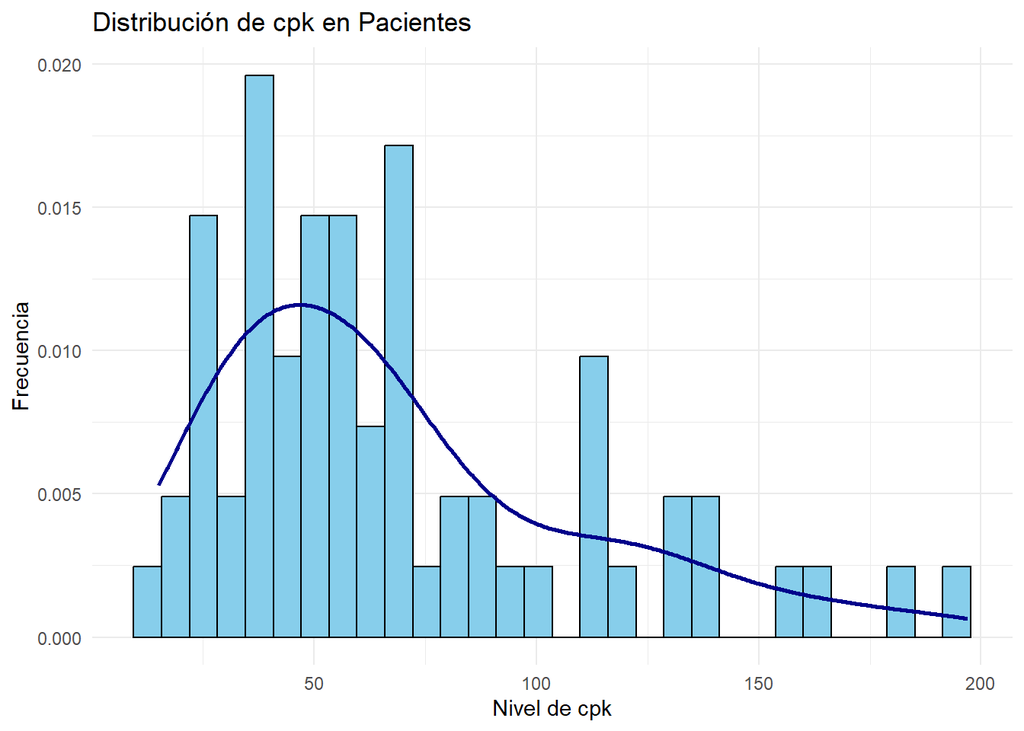

```r
histo_cpk <- ggplot(data = datos_genes, aes(x = cpk)) +
  geom_histogram(aes(y = ..density..), bins = 30, fill = "skyblue", color = "black") +
  geom_density(color = "darkblue", linewidth = 1) +
  labs(title = "Distribución de cpk en Pacientes",
       x = "Nivel de cpk", y = "Frecuencia") +
  theme_minimal()

histo_cpk
```

Combinamos los graficos para una visualización mejor en la comparativa

[figure not shown]

```r
combined_plot <- histo_Glucosa + histo_Leucocitos + histo_Neutrofilos + histo_Chol +
  histo_Hdl + histo_Hierro + histo_igA + histo_igE +
  histo_igG + histo_igN + histo_ldl + histo_pcr +
  histo_Transferrina + histo_Trigliceridos + histo_cpk +
  plot_layout(ncol = 3)

combined_plot
```

b). ¿Qué interpretación sacas de la distribución de los datos de las variables bioquímicas en toda la población?

Por otro lado, algunas variables presentan distribuciones sesgadas o asimétricas, como IgE, PCR, y CPK, lo que indica la presencia de valores atípicos o elevaciones significativas en una porción menor de la población. Estas características pueden deberse a factores subyacentes, como respuestas inmunológicas anormales o condiciones clínicas específicas que alteran estos niveles [3].

La dispersión observada en variables como hierro, transferrina, y leucocitos sugiere una mayor heterogeneidad entre los pacientes, lo que puede reflejar diferencias fisiológicas individuales o una variabilidad en las condiciones de salud de la población analizada. Este patrón de variabilidad biológica es esencial para estudios clínicos, ya que permite identificar subgrupos de pacientes con características únicas que podrían ser relevantes para el diagnóstico, tratamiento, o pronóstico de enfermedades [4] [5].

En general, las distribuciones muestran que las variables bioquímicas tienen niveles de dispersión y centralización diferenciados, lo cual es esperable en un conjunto de datos que incluye pacientes con condiciones de salud diversas. El análisis de estas distribuciones puede proporcionar información valiosa para identificar anomalías clínicas o definir rangos normales en este grupo específico de pacientes[1] [3] [6].

Pregunta 3: Mapea todos los valores de expresión de genes para poder visualizar posibles patrones entre los datos de los pacientes:

a). Para responder esta pregunta, apóyate en un heatmap en el que visualices los datos crudos de todas las variables AQ (expresión de genes).